# Aside

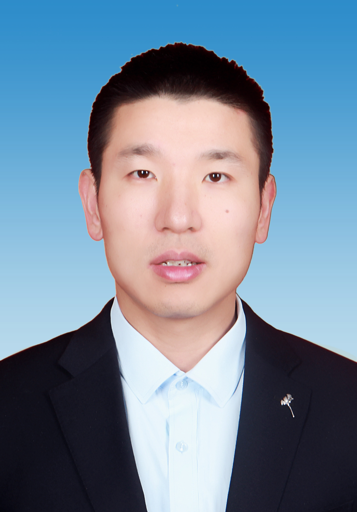

## 联系方式

- (+86) 13269579596
- zhoupenggeni@gmail.com
- github.com/orionzhou

## Disclaimer

最近更新于 2026-01-07.

# Main

## 周鹏

基因的表达是如何受到调控，同时又是如何影响植物表型的？我希望结合传统遗传学、比较基因组学和多组学数据挖掘等手段，以玉米和小麦为模型研究作物在生长发育过程和胁迫条件下的基因表达调控机制，鉴定关键的顺式调控元件和反式作用因子用于作物改良。此外，我将借助大数据分析和多组学数据整合构建植物基因调控网络，训练机器学习模型用于预测基因的时空特异性表达模式，对作物进行精准育种和设计。

## 教育背景

### 博士：植物病理学&生物信息学

明尼苏达大学双城分校

圣保罗，美国

2015 - 2009

- 导师：Nevin D Young

### 硕士：法医遗传学

西安交通大学

中国，西安

2009 - 2007

- 导师：李生斌

### 学士：生物工程&计算机科学

西安交通大学

中国，西安

2007 - 2003

## 工作经历

### 研究员

作物生物信息学

中国农业科学院作物科学研究所，北京

至今 - 2021

### 博士后

植物与微生物学系

明尼苏达大学双城分校

2021 - 2016

- 导师：Nathan M Springer

### 农业信息分析师

应用经济系

明尼苏达超级计算中心

2016 - 2015

### 研究助理

植物病理系

明尼苏达大学双城分校

2015 - 2009

## 职业经历

### 主持项目

N/A

N/A

- 中国农业科学院杰出青年英才计划（2024.01-2028.12）
- 国家重点研发计划课题主持（2023YFF1000104）（2023.12-2028.12）
- 国家基金委优秀青年科学基金（海外）（2023.01-2025.12）
- 科技创新2030生物育种重大专项子课题（2023ZD04076）（2023.12-2025.12）
- 人社部高层次留学人才回国资助（2022.01-2023.12）

## 代表性著作

### [A near Telomere‐to‐telomere Genome Assembly and Graph‐based Pangenome of Tartary Buckwheat (Fagopyrum Tataricum)](https://doi.org/10.1111/pbi.70333)

*Plant Biotechnol J*. 2025:23(12):5797–5799.

N/A

2025

- Li W, Liang H, Sun J, Zhang X, He Q, **Zhou P<sup>#</sup>**, Huo D<sup>#</sup>

### [A complete assembly of the sorghum BTx623 reference genome](http://dx.doi.org/10.1016/j.xplc.2024.100977)

*Plant Commun*. 2024, 5: 100977

N/A

2024

- Deng Y*, **Zhou P***, Li F*, Wang J*, Xie K*, Liang H, Wang C, Liu B, Zhu Z, Zhou W, et al

### [Prediction of conserved and variable heat and cold stress response in maize using cis-regulatory information](https://academic.oup.com/plcell/advance-article/doi/10.1093/plcell/koab267/6420714)

*Plant Cell*. 2022, 34: 514-534

N/A

2022

- **Zhou P**, Enders TA, Myers ZA, Magnusson E, Crisp PA, Noshay J, et al.
- Impact Factor = 11.277

### [Meta Gene Regulatory Networks in Maize Highlight Functionally Relevant Regulatory Interactions](https://doi.org/10.1105/tpc.20.00080)

*Plant Cell*. 2020, 32: 1377-1396.

N/A

2020

- **Zhou P**, Li Z, Magnusson E, Cano FAG, Crisp PA, Noshay J, Grotewold E, HirschC, Briggs SP, Springer NM
- Impact Factor = 11.277

### [Dynamic Patterns of Gene Expression Additivity and Regulatory Variation throughout Maize Development](http://dx.doi.org/10.1016/j.molp.2018.12.015)

*Mol Plant*. 2019, 12: 410-425.

N/A

2019

- **Zhou P**, Hirsch CN, Briggs SP, Springer NM
- Impact Factor = 10.812

## 其他著作

- Citation = 3430
- H-index = 22
- I10-index = 29

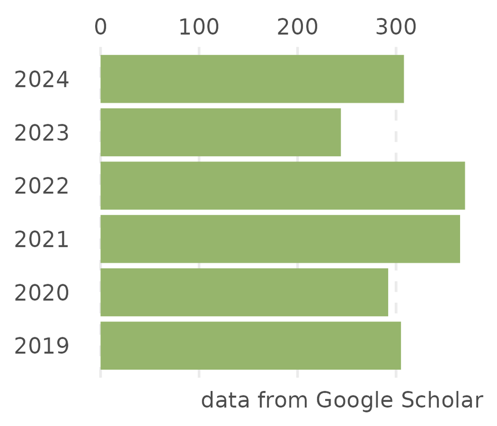

### [Intraspecific diploidization of a halophyte root fungus drives heterosis](http://dx.doi.org/10.1038/s41467-024-49468-7)

*Nat Commun*. 2024:15(1):5872.

N/A

2024

- Li Z, Zhu Z, Qian K, Tang B, Han B, Zhong Z, Fu T, **Zhou P<sup>#</sup>**, Stukenbrock EH, Martin FM<sup>#</sup>, Yuan Z<sup>#</sup>

### [Transcriptome profiling of maize transcription factor mutants to probe gene regulatory network predictions](https://dx.doi.org/10.1093/g3journal/jkae274)

*G3*. 2024:jkae274.

N/A

- Ellison EL, **Zhou P**, Chu Y-H, Hermanson P, Gomez-Cano L, Myers ZA, Abnave A, Gray J, Hirsch CN, Grotewold E, Springer NM

### [Mutator transposon insertions within maize genes often provide a novel outward reading promoter](https://dx.doi.org/10.1093/genetics/iyad171)

*Genetics*. 2023:225(3):iyad171.

N/A

2023

- Ellison EL, **Zhou P**, Hermanson P, Chu Y-H, Read A, Hirsch CN, Grotewold E, Springer NM.

### [Transcriptome Analysis of Developing Wheat Grains at Rapid Expanding Phase Reveals Dynamic Gene Expression Patterns](http://dx.doi.org/10.3390/biology11020281)

*Biology*. 2022, 11: 281.

N/A

2022

- Guan J, Wang Z, Liu S, Kong X, Wang F, Sun G, Geng S, Mao L*, **Zhou P***, Li A*

### [Plant height heterosis is quantitatively associated with expression levels of plastid ribosomal proteins](http://dx.doi.org/10.1073/pnas.2109332118)

*Proc Natl Acad Sci U S A.*. 2021. 118 (47) e2109332118

N/A

2021

- Birdseye D, de Boer LA, Bai H, **Zhou P**, Shen Z, Schmelz EA, Springer NM, Briggs SP

### [Widespread imprinting of transposable elements and young genes in the maize endosperm](http://dx.doi.org/10.1101/2020.04.08.032573)

*PLoS Genetics*. 2021;17: e1009491.

N/A

- Anderson SN, **Zhou P**, Higgins K, Brandvain Y, Springer NM

### [Assessing the regulatory potential of transposable elements using chromatin accessibility profiles of maize transposons](http://dx.doi.org/10.1093/genetics/iyaa003)

*Genetics*. 2021, 217: 1–13.

N/A

- Noshay JM, Marand AP, Anderson SN, **Zhou P**, Guerra MKM, Lu Z, et al

### [Single-parent expression drives dynamic gene expression complementation in maize hybrids](http://dx.doi.org/10.1101/668681)

*Plant Journal*. 2021, 105: 93–107.

N/A

- Li Z, **Zhou P**, Della Coletta R, Zhang T, Brohammer AB, H O’Connor C, et al.

### [The antagonistic MYB paralogs RH1 and RH2 govern anthocyanin leaf markings in Medicago truncatula](http://dx.doi.org/10.1111/nph.17097)

*New Phytologist*. 2021, 229: 3330–3344.

N/A

- Wang C, Ji W, Liu Y, **Zhou P**, Meng Y, Zhang P, et al.

### [Stable unmethylated DNA demarcates expressed genes and their cis-regulatory space in plant genomes](http://dx.doi.org/10.1073/pnas.2010250117)

*Proc Natl Acad Sci U S A.*. 2020, 117: 23991–24000.

N/A

2020

- Crisp PA, Marand AP, Noshay JM, **Zhou P**, Lu Z, Schmitz RJ, et al.

### [Variation and Inheritance of Small RNAs in Maize Inbreds and F1 Hybrids](http://dx.doi.org/10.1104/pp.19.00817)

*Plant Physiol*. 2020, 182: 318-331.

N/A

- Crisp PA, Hammond R, **Zhou P**, Vaillancourt B, Lipzen A, Daum C, et al

### [Monitoring the interplay between transposable element families and DNA methylation in maize](http://dx.doi.org/10.1371/journal.pgen.1008291)

*PLoS Genetics*. 2019, 15: e1008291.

N/A

2019

- Noshay JM, Anderson SN, **Zhou P**, Ji L, Ricci W, Lu Z, et al

### [Transposable elements contribute to dynamic genome content in maize](http://dx.doi.org/10.1111/tpj.14489)

*Plant Journal*. 2019, 100: 1052-1065.

N/A

- Anderson SN, Stitzer MC, Brohammer AB, **Zhou P**, Noshay JM, O’Connor CH, et al

### [Strategies for optimizing BioNano and Dovetail explored through a second reference quality assembly for the legume model](http://dx.doi.org/10.1186/s12864-017-3971-4)

*BMC Genomics*. 2017, 18: 578.

N/A

2017

- Moll KM*, **Zhou P***, Ramaraj T, Fajardo D, Devitt NP, Sadowsky MJ, et al

### [Hybrid assembly with long and short reads improves discovery of gene family expansions](http://dx.doi.org/10.1186/s12864-017-3927-8)

*BMC Genomics*. 2017, 18: 541.

N/A

- Miller JR, **Zhou P**, Mudge J, Gurtowski J, Lee H, Ramaraj T, et al

### [Exploring structural variation and gene family architecture with De Novo assemblies of 15 Medicago genomes](http://dx.doi.org/10.1186/s12864-017-3654-1)

*BMC Genomics*. 2017, 18: 261.

N/A

- **Zhou P**, Silverstein KAT, Ramaraj T, Guhlin J, Denny R, Liu J, et al

### [ODG: Omics database generator - a tool for generating, querying, and analyzing multi-omics comparative databases to facilitate biological understanding](http://dx.doi.org/10.1186/s12859-017-1777-7)

*BMC Bioinformatics*. 2017, 18: 367.

N/A

- Guhlin J, Silverstein KAT, **Zhou P**, Tiffin P, Young ND

### [Exploring structural variants in environmentally sensitive gene families](https://doi.org/10.1016/j.pbi.2015.12.012)

*Curr Opin Plant Biol*. 2016, 30: 19–24.

N/A

2016

- Young ND, **Zhou P**, Silverstein KA

### [Genomic signature of adaptation to climate in Medicago truncatula](http://dx.doi.org/10.1534/genetics.113.159319)

*Genetics*. 2014, 196: 1263–1275.

N/A

2014

- Yoder JB, Stanton-Geddes J, **Zhou P**, Briskine R, Young ND, Tiffin P

### [Selection, genome-wide fitness effects and evolutionary rates in the model legume Medicago truncatula](http://dx.doi.org/10.1111/mec.12329)

N/A

2013

- Paape T, Bataillon T, **Zhou P**, J Y Kono T, Briskine R, Young ND, et al

### [Detecting small plant peptides using SPADA (Small Peptide Alignment Discovery Application)](http://dx.doi.org/10.1186/1471-2105-14-335)

*BMC Bioinformatics*. 2013, 14: 335.

N/A

- **Zhou P**, Silverstein KA, Gao L, Walton JD, Nallu S, Guhlin J, et al

### [Whole-genome nucleotide diversity, recombination, and linkage disequilibrium in the model legume Medicago truncatula](http://pubs.rsc.org/en/Content/ArticleLanding/2016/MB/C5MB00663E)

*Proc Natl Acad Sci U S A*. 2013, 22: 3525–3538.

N/A

- Branca A, Paape TD, **Zhou P**, Briskine R, Farmer AD, Mudge J, et al

### [Fine-scale population recombination rates, hotspots, and correlates of recombination in the Medicago truncatula genome)](http://dx.doi.org/10.1093/gbe/evs046)

*Genome Biol Evol*. 2012, 4: 726–737.

N/A

2012

- Paape T, **Zhou P**, Branca A, Briskine R, Young N, Tiffin P

### [The Medicago genome provides insight into the evolution of rhizobial symbioses](http://dx.doi.org/10.1038/nature10625)

*Nature*. 2011, 480: 520-524.

N/A

2011

- Young ND, Debellé F, Oldroyd GED, …, **Zhou P**, …, et al
- ESI Highly Cited Paper